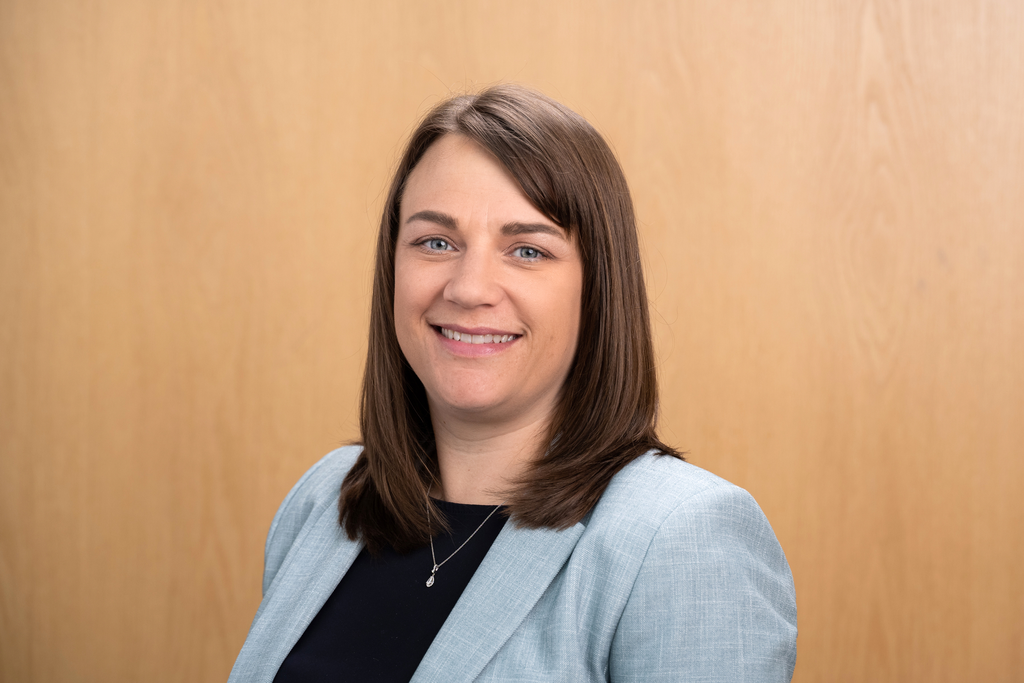

# Andrea S. Aldrich

I am an Assistant Professor of Political Science at the University of Pittsburgh. Prior to this I was a Senior Lecturer and Director of Undergraduate Studies in the Department of Political Science at Yale University. My research focuses on political representation, gender, and comparative political institutions. I examine the representation of women, exploring the conditions that foster women’s political leadership and the consequences of women in power within political parties and legislative institutions. The cornerstone of my research is the multifaceted role of political party institutions and electoral rules in shaping representation. I primarily investigate how the internal organization of parties promotes women to positions of political power and how party structures interact with system-level political institutions. My work is largely based in Europe, studying parties in both Western and Eastern Europe as well as the European Union.

My research has been published in [The Journal of Politics](https://www.journals.uchicago.edu/doi/10.1086/727603), [Party Politics](https://journals.sagepub.com/doi/10.1177/1354068818806630), and [Politics & Gender](https://www.cambridge.org/core/journals/politics-and-gender/article/pandemic-performance-women-leaders-in-the-covid19-crisis/579B3EA9BE0CD8215EE2E74257252FED), among others. My book, [Gender Quotas as Game Changers for the Recruitment, Selection, and Performance of Elected Politician](https://academic.oup.com/book/59689/), co-authored with [William Daniel](https://sites.google.com/site/wdaniel127/), is available from Oxford University Press. My second book was also just published by Cambridge University Press. [Glass Ceilings, Glass Cliffs, and Quicksands: Gendered Party Leadership in Parliamentary Systems](https://www.cambridge.org/core/elements/glass-ceilings-glass-cliffs-and-quicksands/1F6160BF34331177152D800C2514AEBD/), co-authored with [Zeynep Somer-Topcu](https://zeynepsomer.com/).

[figure not shown]

[figure not shown]

### Research

**Books**

**Abstract**

Academic scholarship indicates that gender quotas can help to attain equal representation for men and women in elected office, yet less is known about what else they achieve. As moments of positive disruption, the implementation of gender quotas acts as a game changer for the full system of democratically elected politics. This book shows that quotas offer new opportunities for aspiring politicians to be recruited and seek election, as well as more gender equal ways of winning them. Findings show that legislators elected under quotas are more likely to display the valuable background qualifications necessary to succeed in office. By tracing the careers of legislators across subnational, national, and European levels from over forty years of office, it offers conclusive evidence that quotas can have profound effects on the nature of political careers for both men and women. In doing so, it unites new and existing theories and data to speak to the broader study of legislative and party politics, European Union studies, and political careers.

*[Glass Ceilings, Glass Cliffs, and Quicksands: Gendered Party Leadership in Parliamentary Systems](https://www.dropbox.com/s/d50waxtrko3bxxp/Gender_and_Party_Leadership_Change_Book%20%283%29.pdf?raw=1)* w/ Zeynep Somer-Topcu. Cambridge Elements Gender and Politics Series, 2025.

**Abstract**

While the number of women in office around the world is on the rise, men continue to outnumber women at high rates in top leadership positions. There are many reasons why it remains difficult for women to reach powerful positions within politics that cover myriad electoral, institutional, and individual conditions. In this monograph, we examine women’s careers as political party leaders. We seek to understand what conditions make it more likely that women are selected as party leaders, run as candidates for party leadership, and how gender impacts leadership tenures. Tracking the careers of 269 political party leaders in eleven advanced parliamentary democracies between 1980 and 2020, we provide rich, descriptive data on all stages of the leadership selection and removal process and test the relationship between gender and leadership selection, challenges to party leadership, and removal of leaders. Our analyses focus on performance indicators, selection procedures, gender equality in politics, and their interactions as factors affecting the selection and survival of women party leaders.

**Recent Publications**

“A Rainbow Ceiling? Sexual Orientation and Party Leader Legitimacy” w/ Joseph Francesco Cozza, Gonzalo Di Landro, and Zeynep Somer-Topcu *Forthcoming at the British Journal of Political Science.*

**Abstract**

How do citizens evaluate queer party leaders? While recent scholarship has provided a window into how individuals evaluate queer legislators and candidates for elected office, few studies have examined voter evaluations of queer individuals in positions of political leadership. This study assesses public perceptions of queer party leaders, with a focus on leader legitimacy. Results from a conjoint experiment in the UK indicate that queer leaders are perceived to be less legitimate than straight leaders and that queer men and women face similar penalties. This finding holds regardless of the queer leader’s level of legislative experience. Additionally, the parties that queer politicians lead are perceived to be more left-wing than those led by straight politicians. Finally, right-wing voters, and those who hold homophobic views are more likely to penalize queer leaders. Thus, queer party leaders are in disadvantage compared to their straight counterparts.

“[Gender Quotas and the Qualifications of Parliamentarians](https://www.journals.uchicago.edu/doi/full/10.1086/727603)” w/ William T. Daniel, *The Journal of Politics*, 86(2)2024.

**Abstract and Supplemental Materials**

Gender quotas in legislative elections are a central component of institutional reform to increase women’s inclusion in politics. We investigate how quotas affect women’s representation and the qualifications of parliamentarians from all EU member states over the last 40 years, which had 11 countries pass gender quotas legislation. We capitalize on the unique variation of national electoral systems used in European Parliament elections to all nine legislative sessions (1979-2019) and investigate the relationship between quotas and the qualifications of parliamentarians. We provide compelling evidence that the passage of quota legislation is associated with higher levels of educational attainment among legislators. By examining the complete elected history of the European Parliament, we are able to provide generalizable and robust support for the impact of quotas on legislator qualities in a way that has thus far been observed in only single country contexts and fixed time periods.

[Online Appendices](https://www.dropbox.com/home/shared_folders/Quotas_Aldrich_Daniel/JOP%20Final%20Submission?preview=Online+Appendices.pdf)

[Replication Files](https://doi.org/10.7910/DVN/GXWHFG)

“[Pandemic Performance: Women Leaders in the Covid-19 Crisis](https://www.cambridge.org/core/journals/politics-and-gender/article/pandemic-performance-women-leaders-in-the-covid19-crisis/579B3EA9BE0CD8215EE2E74257252FED)” w/ Nicholas J. Lotito, *Politics & Gender*, 16(4): 960-967. (2020)

**Abstract and Supplemental Materials**

Media outlets have reported that women leaders around the globe are managing the COVID-19 crisis better than their male counterparts, responding faster and communicating better about pandemic policies. In this article, we examine empirical data on the timing of policy responses from the Coronavirus Government Response Tracker to determine whether and how countries led by women reacted differently to the pandemic. Exploring the relationship between the gender of leaders and legislators and the timing of stay-at-home orders, school closures, and coordinated public information campaigns, we find no statistical evidence supporting popular claims in the media. However, we find some evidence that the level of gender equality in legislatures is related to school closures, a policy with clear gendered consequences. These conclusions are an important first step in understanding the potentially gendered nature of the crisis response and identifying new avenues for research.

[Online Appendix](https://www.dropbox.com/s/tmq8hnnun6fjhai/Online%20Appendix.pdf?dl=0)

[Replication Files](https://doi.org/10.7910/DVN/FNHALO)

“[Party Organization and Gender in European Elections](https://journals.sagepub.com/doi/10.1177/1354068818806630)” *Party Politics*, 26 (5): 675-688. (2020)

**Abstract and Supplemental Materials**

Political parties often monopolize the flow of politicians into elected office making it important to understand when, and under what conditions, parties are more or less likely to promote gender equality in representation. This article argues that party choices to nominate women in elections are conditional on the centralization of candidate selection within the party. Gender quotas and characteristics of the electoral environment have differential effects on candidate lists across party types. Leveraging data at the party level, I test when it is electorally feasible and organizationally possible for parties to nominate women for office. I find that candidate selection procedures condition the effects of party strategy and characteristics of the electoral environment on the percentage of women on electoral lists. The results provide insight into how strategic party choices, attenuated by electoral considerations and organization, impact the diversity of representation in political institutions.

[Replication Files](https://doi.org/10.7910/DVN/DHKFCT%22Replication%20Files%22)

“The Consequences of Quotas: Assessing the Effect of Varied Gender Quotas on Legislator Experience in the European Parliament” w/ William T Daniel, *Politics & Gender*, 16(3): 738-767 (2019)

**Abstract and Supplemental Materials**

This article explores the consequences of quotas on the level of diversity observed in legislators’ professional and political experience. We examine how party system and electoral system features that are meant to favor female representation, such as gender quotas for candidate selection or placement mandates on electoral lists, affect the composition of legislatures by altering the mix of professional and political qualifications held by its members. Using data collected for all legislators initially seated to the current session of the European Parliament, one of the largest and most diverse democratically elected legislatures in the world, we find that quotas eliminate gendered differences in experience within the institution, particularly when used in conjunction with placement mandates that ensure female candidates are featured on electoral lists in viable positions. Electoral institutions can generally help to “level the playing field” between the backgrounds of men and women in elected office while increasing the presence of desirable qualities among European Parliament representatives of both genders.

[Online Appendix](https://www.dropbox.com/home/Published%20Articles/Politics%20and%20Gender%202019?preview=Online+Appendix.pdf%22)

“[National Political Parties and Career Paths to the European Parliament](https://onlinelibrary.wiley.com/doi/abs/10.1111/jcms.12741)” *JCMS: Journal of Common Market Studies*, 56(6): 1283-1304. (2018)

**Abstract and Supplemental Materials**

This paper explores how career paths leading to the European Parliament (EP) are influenced by the strategic goals of national political parties. Considering both individual career factors and the national electoral fate of political parties, it determines what conditions increase the likelihood that experienced or inexperienced politicians serve in the EP. Experienced politicians are more likely to reach the EP when they serve vote-seeking and policy-seeking parties while inexperienced politicians are more likely to enter the EP when their parties are opportunity seeking. Overall, I find the role of individual ambition is conditioned by party strategy to determine the institutional composition of the EP, contributing to a growing literature on the strategic use of European elections by national political parties. It suggests that the electoral goals of parties should be examined in order to understand the nature of democratic representation in the European Union.

[Online Appendix](https://www.dropbox.com/s/1dqhvux6o08m3sm/supplement.pdf?dl=0%22)

**Selected Work in Progress**

“The Quicksand Paradox: Gender, Expectations, and Information in Party Leadership Evaluations.” w/ Zeynep Somer Topcu

“Participation, Gender, and Legitimacy in Party Leader Selection” w/ Joseph Francesco Cozza, Gonzalo Di Landro, and Zeynep Somer-Topcu

**Abstract**

In political science, several experiments studying the effect of gender on candidate choice have identified a general preference for women candidates in electoral contests. However, women’s representation in politics continues to lag behind men’s in almost every setting, including the most prestigious positions of political leadership. In real world settings, a disconnect remains between this seeming preference for women and the actual selection of women as political leaders. Using observational data at the party level, we show that even when women are candidates for leadership, a strong preference remains for male leaders. However, once selected, women leaders perform just as well as men, if not better, under similar political conditions. To understand the relationship between gender and leadership, we explore how competition for leadership posts impacts the legitimacy of leaders and investigate whether this a gendered process. We first establish substantive legitimacy as the idea that leaders are viewed as having earned their positions, are strong enough to lead the party, will work hard on behalf of the party, and will help the party win. Then we test, in an experimental design, how gender and competition work together to impact the evaluation of leaders. We first test for differences in legitimacy across genders related to outright gender bias. Then we test how gender and legitimacy are mediated through the competitiveness of intraparty elections. We hypothesize that while men may be perceived as more substantively legitimate overall, women that win highly competitive contests will be perceived as more legitimate than men, having proved they can win these types contests.

“Policy and Personal Valence: Party Leaders and Gendered Electoral Environments”

**Abstract**

This paper investigates the relationship between the use of valence in elections and the gender of political party leaders. Using the Comparative Campaign Dynamics Project data (Debus, Somer-Topcu and Tavits 2018), I explore valence statements used by parties in elections, both personal and policy related, to ask if, and when, parties with woman leaders are more likely to use, and be targets of, strategic valence statements. Given previous research, I argue that the use of valence in electoral campaigns will be gendered in nature, with women party leaders more likely to experience valence attacks in campaigns but less likely to use valence in the same environment. I find there are many unexpected differences in the use of valence in campaigns that are associated with the gender of the party leader. Specffically, parties with women party leaders are less likely to engage in valance campaigns and are also less likely to be the subject of valance attacks.

### Teaching

- Senior Colloquium ([2025](https://www.dropbox.com/scl/fi/qckkduzpmwode0ljsrki0/plsc_4900.pdf?rlkey=mx01dm3qyuivl1zc8x0qne9uy&st=4yzwrk23&raw=1), 2026) (Seminar)
- Researching Women & Politics ([2024](https://www.dropbox.com/scl/fi/kwmsrhwkf436a6be3bwz9/PLSC_460_Researching_Women_and_Politics.pdf?rlkey=eecqrlsn7mn39nb06ig121gje&st=busm0yta&raw=1)) (Seminar)
- Women, Politics, and Policy (2023, 2024, [2025](https://www.dropbox.com/scl/fi/4hh4j0i4k5ata1q4qy2o7/PLSC_2253_Fall_2025.pdf?rlkey=3fyd6rtvx9bc2yka0oadpjnh7&st=30l84q62&raw=1)) (Lecture)
- Women & Politics (2018, 2019, [2020](https://www.dropbox.com/s/r9ikm460q6fmo47/PLSC220.Fall20.pdf?raw=1), 2022) (Seminar)
- Comparative Political Parties and Electoral Systems (2019, 2020, [2022](https://www.dropbox.com/s/fqqsb986ku9dkml/Comparative.Political.Parties.2022.pdf?raw=1)) (Seminar)
- Legacies of Communism and Conflict in Europe (Lecture: 2017, 2018, [2019](https://www.dropbox.com/s/2e0fpf8f27fyi4d/PLSC400.Fall2019.pdf?raw=1)), Seminar: [2021](https://www.dropbox.com/s/iitda2ch9ddig5l/PLSC400.Hybrid.2021.pdf?raw=1)) (Lecture)
- Comparative Legislatures ([2017](https://www.dropbox.com/s/5mk3foe5tnkgrbr/Comparative.Legislatures.pdf?raw=1)) (Seminar)